# LLM & Human Possibilities, Study 1

2026-05-07

# Read in Data

Two CSV files were exported from Qualtrics, one per experimental condition (LLM-generated options; Human-generated options). The first two rows of each Qualtrics export contain metadata and are removed. Column names are standardised to snake_case using `clean_names()`. For the LLM file, condition prefixes are renamed from `c3`/`c4` to `c1`/`c2` to match the Human file structure.

# Participant Exclusions

Participants were excluded if: (1) their reCAPTCHA score indicated bot-like behaviour (score ≤ 0.5), or (2) they reported a faulty LLM option display via the post-study feedback question.

# Demographics

Gender and Ethnicity

| Category | Group | N |
| --- | --- | --- |
| Female | Gender | 346 |
| Male | Gender | 254 |
| Non-binary | Gender | 9 |
| Prefer not to say | Gender | 1 |
| Other | Gender | 1 |
| Caucasian/White | Ethnicity | 359 |
| Black/African | Ethnicity | 147 |
| Hispanic/Latinx | Ethnicity | 37 |
| Alaskan or American Indian | Ethnicity | 6 |
| Asian | Ethnicity | 41 |
| Middle Eastern or Northern African | Ethnicity | 1 |
| Multiethnic | Ethnicity | 11 |
| Prefer not to disclose | Ethnicity | 5 |

Age and Study Duration

| Measure | Mean | SD |
| --- | --- | --- |
| Age (years) | 40.79 | 13.84 |
| Study duration (minutes) | 15.95 | 8.24 |

# Data Preparation

## Main Dataframe

The raw data are reshaped from wide to long format and back, parsing each column name to extract: the experimental condition (`c1` = judgment last, `c2` = judgment first), the scenario number (1–9), and the response type (probability, morality, and normality ratings for each of 5 generated options, the actual action, blame, and counterfactual ratings). Participants who reported display issues in either feedback question are removed at this stage.

# Analysis

## Internal Consistency of Ratings

The three rating dimensions (probability, morality, normality) were examined for internal consistency across all generated options.

```r
ratings_matrix <- exp1_wide.df %>%
  select(probability, morality, normality) %>%
  filter(complete.cases(.))

alpha_result <- psych::alpha(ratings_matrix)

# Average inter-rating r (mean of pairwise correlations)
cor_matrix <- cor(ratings_matrix, use = "complete.obs")
mean_r <- mean(cor_matrix[upper.tri(cor_matrix)])

# Summary: Cronbach's alpha and average inter-rating r
data.frame(
  measure = c("Cronbach's alpha", "Average inter-rating r"),
  value   = round(c(alpha_result$total$raw_alpha, mean_r), 2)
)
```

| measure | value |
| --- | --- |
| Cronbach's alpha | 0.87 |
| Average inter-rating r | 0.69 |

```r
# Corrected rating-composite correlations
round(alpha_result$item.stats[, "r.cor", drop = FALSE], 2)
```

|  | r.cor |
| --- | --- |
| probability | 0.81 |
| morality | 0.72 |
| normality | 0.90 |

## Sample Sum

For each participant and scenario, we calculate the **sample sum**: the total amount by which the generated options exceed the value of the agent’s actual action. Formally, for each option whose composite value exceeds the action’s composite value, we sum the difference. Participants missing actual action ratings across all scenarios are excluded; for the small number of cases where a single scenario’s actual action rating is missing, that scenario is skipped and the corresponding sample sum entry is left as NA (excluded from the blame models below).

```r
# Identify and exclude participants missing ALL actual action ratings
participant_numbers <- exp1_long_act.df %>%
  filter(response_category == "avg") %>%
  group_by(participant) %>%
  summarise(all_missing = all(is.na(response)), .groups = "drop") %>%
  filter(all_missing) %>%
  pull(participant)

withinData <- exp1_long_avg.df %>%
  mutate(sampleSum = NA) %>%
  ungroup() %>%
  filter(!participant %in% participant_numbers)

for (subj in unique(withinData$participant)) {
  d <- withinData %>% filter(participant == subj)

  for (e in unique(d$experiment)) {
    for (c in unique(d$scenario)) {

      # Composite ratings for each generated option
      pgSamp <- exp1_long_avg.df %>%
        filter(participant == subj, scenario == c,
               experiment == e, response_category == "avg") %>%
        pull(response)

      # Composite rating for the actual action
      a_val <- exp1_long_act.df %>%
        filter(participant == subj, scenario == c,
               experiment == e, response_category == "avg") %>%
        pull(response)

      # Skip if actual action rating is missing for this scenario
      if (length(a_val) == 0 || is.na(a_val)) next

      # Sample sum: total excess of generated options over the actual action
      withinData$sampleSum[
        withinData$participant == subj &
        withinData$scenario    == c    &
        withinData$experiment  == e
      ] <- sum(pgSamp[pgSamp > a_val] - a_val)
    }
  }
}
```

## Value of Generated Options

We used linear mixed-effects models (LMERs) to examine whether the composite value of generated options differed between experimental conditions (LLM vs. Human) and across generation order (options 1–5). Scenario and participant were included as crossed random intercepts. Models were compared using likelihood ratio tests (ML estimation).

```r
model_0 <- lmer(avg ~ 1 + (1 | scenario) + (1 | participant),
                data = exp1_wide.df, REML = FALSE)

model_1 <- lmer(avg ~ experiment + (1 | scenario) + (1 | participant),
                data = exp1_wide.df, REML = FALSE)

model_2 <- lmer(avg ~ experiment + response_order + (1 | scenario) + (1 | participant),
                data = exp1_wide.df, REML = FALSE)

model_3 <- lmer(avg ~ experiment * response_order + (1 | scenario) + (1 | participant),
                data = exp1_wide.df, REML = FALSE)

anova(model_0, model_1, model_2, model_3)
```

|  | npar | AIC | BIC | logLik | deviance | Chisq | Df | Pr(>Chisq) |
| --- | --- | --- | --- | --- | --- | --- | --- | --- |
| model_0 | 4 | 84264.38 | 84292.88 | -42128.19 | 84256.38 | NA | NA | NA |
| model_1 | 5 | 84265.55 | 84301.17 | -42127.77 | 84255.55 | 0.8355673 | 1 | 3.606676e-01 |
| model_2 | 9 | 83876.31 | 83940.43 | -41929.16 | 83858.31 | 397.2370057 | 4 | 1.099717e-84 |
| model_3 | 13 | 83856.15 | 83948.78 | -41915.08 | 83830.15 | 28.1571765 | 4 | 1.159064e-05 |

```r
# Model 2: main effects only
cat("\n--- Model 2: experiment + response_order ---\n")
```

```
##
## --- Model 2: experiment + response_order ---
```

```r
coef(summary(model_2))
```

```
##                       Estimate Std. Error         df      t value     Pr(>|t|)
## (Intercept)       71.245354472  1.2807331   19.32211  55.62857385 8.515426e-23
## experimentLLM      0.979704669  1.0712429  610.41203   0.91454948 3.607893e-01
## response_order.L -10.301573036  0.5132756 8560.89425 -20.07025476 1.360197e-87
## response_order.Q   0.997862643  0.5132756 8560.89425   1.94410673 5.191530e-02
## response_order.C  -0.007922918  0.5132756 8560.89425  -0.01543599 9.876847e-01
## response_order^4  -0.024998245  0.5132756 8560.89425  -0.04870335 9.611568e-01
```

```r
# Model 3: interaction
cat("\n--- Model 3: experiment × response_order ---\n")
```

```
##
## --- Model 3: experiment × response_order ---
```

```r
emm_options(pbkrtest.limit = 50000, lmerTest.limit = 50000)

# Estimated marginal means for each experiment × response_order cell
emm <- emmeans(model_3, ~ experiment * response_order)

# LLM vs. Human at each generation position
contrast(emm, method = "revpairwise", by = "response_order")
```

```
## response_order = 1:
##  contrast    estimate   SE   df t.ratio p.value
##  LLM - Human    0.749 1.41 1769   0.531  0.5958
##
## response_order = 2:
##  contrast    estimate   SE   df t.ratio p.value
##  LLM - Human   -2.498 1.41 1769  -1.770  0.0769
##
## response_order = 3:
##  contrast    estimate   SE   df t.ratio p.value
##  LLM - Human   -0.388 1.41 1769  -0.275  0.7836
##
## response_order = 4:
##  contrast    estimate   SE   df t.ratio p.value
##  LLM - Human    2.347 1.41 1769   1.663  0.0965
##
## response_order = 5:
##  contrast    estimate   SE   df t.ratio p.value
##  LLM - Human    4.689 1.41 1769   3.323  0.0009
##
## Degrees-of-freedom method: kenward-roger
```

```r
# Change across generation positions within each condition (vs. position 1)
contrast(emm, method = "trt.vs.ctrl", ref = 1, by = "experiment")
```

```
## experiment = Human:
##  contrast                          estimate   SE   df t.ratio p.value
##  response_order2 - response_order1    -2.38 1.04 8568  -2.295  0.0749
##  response_order3 - response_order1    -7.02 1.04 8568  -6.753  <.0001
##  response_order4 - response_order1   -11.38 1.04 8568 -10.948  <.0001
##  response_order5 - response_order1   -15.06 1.04 8568 -14.492  <.0001
##
## experiment = LLM:
##  contrast                          estimate   SE   df t.ratio p.value
##  response_order2 - response_order1    -5.63 1.01 8568  -5.563  <.0001
##  response_order3 - response_order1    -8.15 1.01 8568  -8.055  <.0001
##  response_order4 - response_order1    -9.78 1.01 8568  -9.660  <.0001
##  response_order5 - response_order1   -11.12 1.01 8568 -10.983  <.0001
##
## Degrees-of-freedom method: kenward-roger
## P value adjustment: dunnettx method for 4 tests
```

### Descriptive Statistics: Value of Generated Options

Mean composite value of generated options by condition

| Condition | Mean | SD |
| --- | --- | --- |
| Human | 71.23 | 25.82 |
| LLM | 72.22 | 25.56 |

Mean composite value of generated options by condition and generation position

| Condition | Generation position | Mean | SD |
| --- | --- | --- | --- |
| Human | 1 | 78.39 | 22.33 |
| Human | 2 | 76.01 | 22.24 |
| Human | 3 | 71.38 | 25.24 |
| Human | 4 | 67.02 | 26.77 |
| Human | 5 | 63.34 | 28.88 |
| LLM | 1 | 79.16 | 22.02 |
| LLM | 2 | 73.53 | 25.74 |
| LLM | 3 | 71.01 | 25.98 |
| LLM | 4 | 69.38 | 26.15 |
| LLM | 5 | 68.04 | 26.21 |

## Value of Actual Action

We tested whether participants’ ratings of their own actual action differed between conditions.

```r
model_act <- lmer(avg ~ experiment + (1 | scenario) + (1 | participant),
                  data = exp1_wide_act.df, REML = FALSE)

anova(model_act)
```

|  | Sum Sq | Mean Sq | NumDF | DenDF | F value | Pr(>F) |
| --- | --- | --- | --- | --- | --- | --- |
| experiment | 41884.29 | 41884.29 | 1 | 603.3289 | 76.00751 | 2.73261e-17 |

```r
coef(summary(model_act))
```

```
##                Estimate Std. Error         df   t value     Pr(>|t|)
## (Intercept)    67.98724   3.602043   9.947539 18.874632 4.057173e-09
## experimentLLM -11.96783   1.372737 603.328896 -8.718229 2.732610e-17
```

### Descriptive Statistics: Value of Actual Action

Mean composite value of actual action by condition

| Condition | Mean | SD |
| --- | --- | --- |
| Human | 68.02 | 26.61 |
| LLM | 55.82 | 28.46 |

## Effect of Experimental Condition and Sample Sum on Blame Ratings

We examined whether blame ratings were predicted by experimental condition (LLM vs. Human), the sample sum, or both. All models included scenario and participant as crossed random intercepts. Four rows with missing sample sums (due to a missing actual action rating for one scenario) were excluded, leaving a consistent dataset across all model comparisons.

```r
# Null model
model_null <- lmer(blame ~ 1 + (1 | scenario) + (1 | participant),
                   data = exp1_blame.df, REML = FALSE)

# Experiment only
model_exp <- lmer(blame ~ experiment + (1 | scenario) + (1 | participant),
                  data = exp1_blame.df, REML = FALSE)

# Sample sum only
model_sample <- lmer(blame ~ sampleSum + (1 | scenario) + (1 | participant),
                     data = exp1_blame.df, REML = FALSE)

# Experiment + sample sum (full model)
full_model <- lmer(blame ~ experiment + sampleSum + (1 | scenario) + (1 | participant),
                   data = exp1_blame.df, REML = FALSE)

# Model comparison: does experiment condition predict blame?
cat("--- Null vs. experiment ---\n")
```

```
## --- Null vs. experiment ---
```

```r
anova(model_null, model_exp)
```

|  | npar | AIC | BIC | logLik | deviance | Chisq | Df | Pr(>Chisq) |
| --- | --- | --- | --- | --- | --- | --- | --- | --- |
| model_null | 4 | 17815.69 | 17837.73 | -8903.845 | 17807.69 | NA | NA | NA |
| model_exp | 5 | 17801.25 | 17828.80 | -8895.623 | 17791.25 | 16.44247 | 1 | 5.014885e-05 |

```r
coef(summary(model_exp))
```

```
##                Estimate Std. Error        df  t value     Pr(>|t|)
## (Intercept)   31.974189   4.224655  10.33691 7.568473 1.578809e-05
## experimentLLM  7.399743   1.812233 607.53558 4.083217 5.036053e-05
```

```r
# Model comparison: does sample sum add explanatory power over experiment alone?
cat("\n--- Experiment vs. experiment + sample sum ---\n")
```

```
##
## --- Experiment vs. experiment + sample sum ---
```

```r
anova(model_exp, full_model)
```

|  | npar | AIC | BIC | logLik | deviance | Chisq | Df | Pr(>Chisq) |
| --- | --- | --- | --- | --- | --- | --- | --- | --- |
| model_exp | 5 | 17801.25 | 17828.8 | -8895.623 | 17791.25 | NA | NA | NA |
| full_model | 6 | 17749.73 | 17782.8 | -8868.867 | 17737.73 | 53.51209 | 1 | 2.570069e-13 |

```r
coef(summary(full_model))
```

```
##                  Estimate  Std. Error         df  t value     Pr(>|t|)
## (Intercept)   28.09483362 4.421585392   10.54254 6.354018 6.558640e-05
## experimentLLM  5.20760092 1.843891404  627.05373 2.824245 4.889821e-03
## sampleSum      0.05509997 0.007425856 1799.70128 7.420016 1.795949e-13
```

### Descriptive Statistics: Blame Ratings

Mean blame rating by condition

| Condition | Mean | SD |
| --- | --- | --- |
| Human | 32.08 | 34.35 |
| LLM | 39.33 | 34.36 |

# Figures

## Blame Ratings by Condition

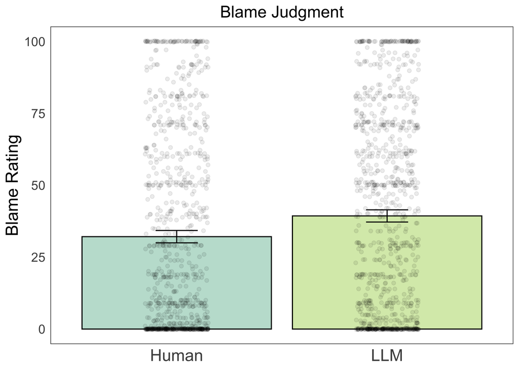

## Value of Generated Options by Generation Number

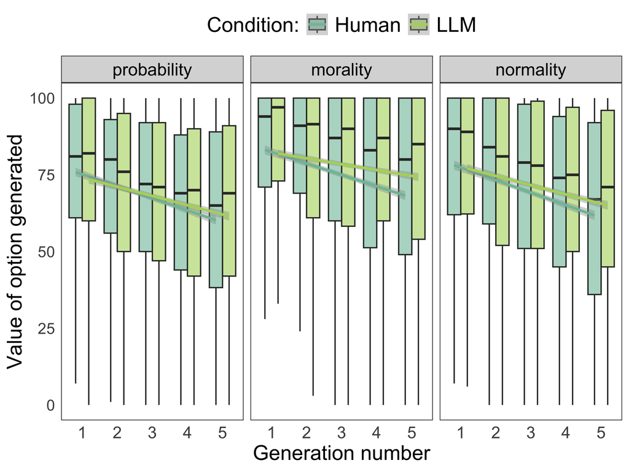

## Value of Chosen Action by Condition

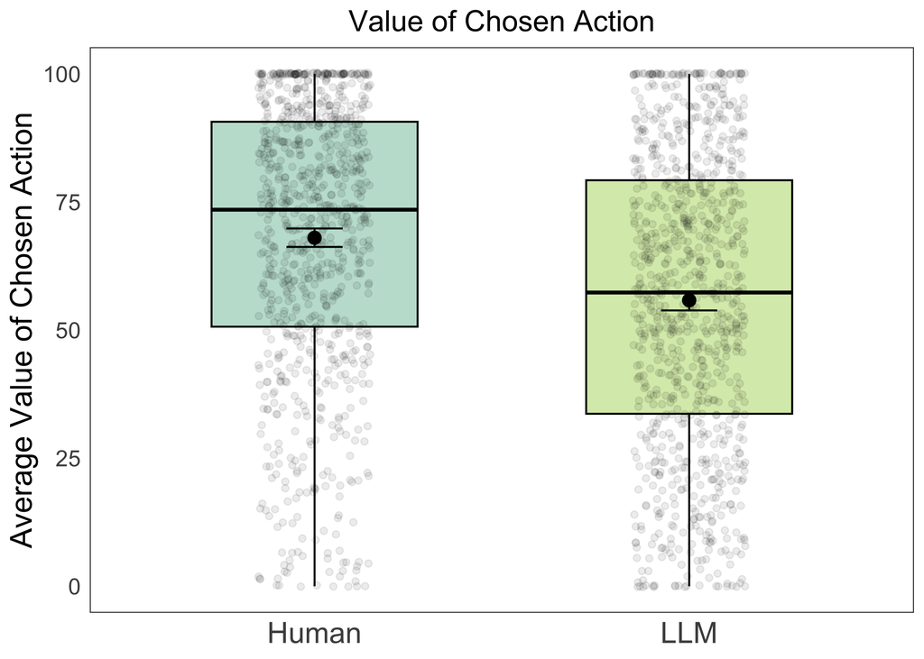